# TIMSCONVERT comparison

Yinyue Zhu

2025-07-22

### Introduction

In this vignette, we will compare TIMSImaging workflow with existing method that ignores ion mobility in terms of ion image quality. TIMSCONVERT is an open-source tool to convert general Bruker raw data into open formats. Specifically, it outputs imzML for MALDI-TIMS-MS imaging data, either with ion mobility or not. However, it does not do any pre-processing.

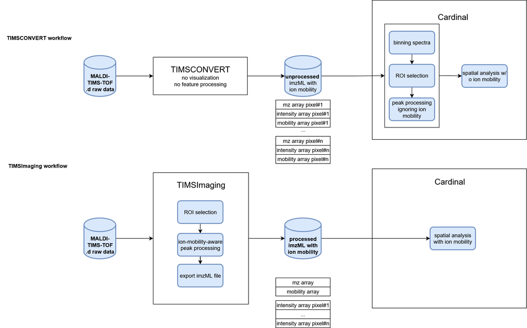

### Process data from TIMSCONVERT

Load the imzML data from TIMSCONVERT, which is obtained by running the shell script.

```r
msa <- readMSIData("D:\\dataset\\Melanie_case_study\\Kidney_MS1_ITO6.imzML")
msa
```

```
## MSImagingArrays with 38267 spectra
## spectraData(2): intensity, mz
## pixelData(3): x, y, run
## coord(2): x = 204...753, y = 99...442
## runNames(1): Kidney_MS1_ITO6
## experimentData(5): spectrumType, spectrumRepresentation, lineScanSequence, scanType, lineScanDirection
## centroided: TRUE
## continuous: FALSE
```

TIMSCONVERT keeped ion mobility in the imzML data, however the peak process functions in Cardinal cannot take advantage of it. Here we bin the spectra to project data points with the same m/z but different ion mobilities together.

```r
mse_binned <- bin(msa, resolution=20, units="ppm")
mse<-summarizePixels(mse_binned)
```

To reduce the computation, we only process the kidney tissue region in following steps.

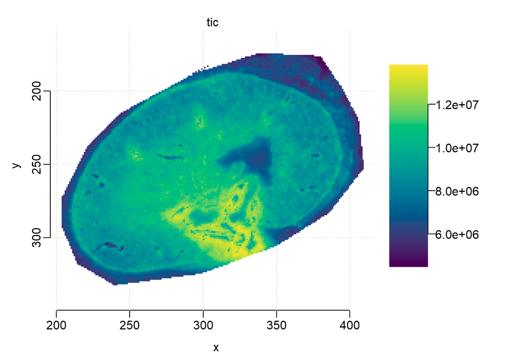

```r
kidney <- subsetPixels(mse, x<500)
image(kidney, 'tic')
```

Plot one spectrum, though the data is centroided on m/z dimension by the instrument, it looks more similar with a profile spectrum after projection.

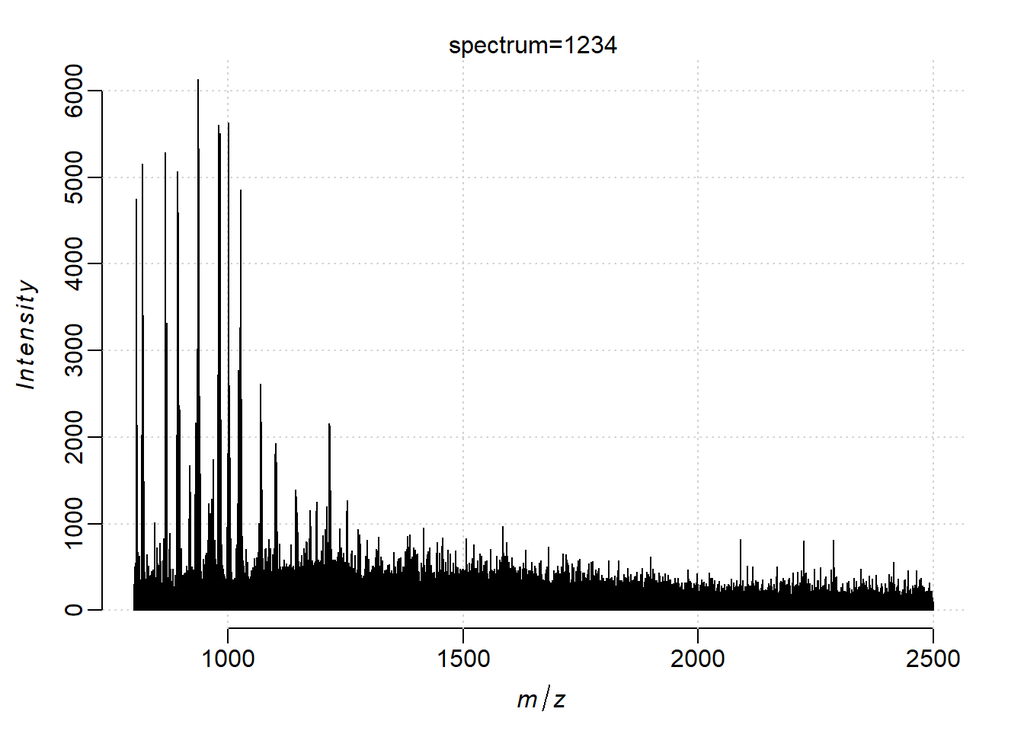

```r
plot(kidney, i=1234)
```

Treat the data as profile spectra and process it(to reduce features)

```r
kidney <- subsetPixels(mse_binned, x<500)
centroided(kidney)<-FALSE
set.seed(1, kind="L'Ecuyer-CMRG")
#kidney <- normalize(kidney, method='rms')
peaks <- peakProcess(kidney, SNR=3, tolerance=200, units="ppm")
```

### Comparing ion images

Then we load the processed data from TIMSImaging, which is already peak-picked.

```r
peaks_timsimaging <- readMSIData("D:\\dataset\\Melanie_case_study\\mouse_kidney.imzML")
peaks_timsimaging
```

```
## MSImagingExperiment with 3110 features and 22978 spectra
## spectraData(1): intensity
## featureData(1): mz
## pixelData(3): x, y, run
## coord(2): x = 204...409, y = 175...332
## runNames(1): mouse_kidney
## experimentData(5): spectrumType, spectrumRepresentation, lineScanSequence, scanType, lineScanDirection
## mass range:  800.2957 to 1760.7449
## centroided: TRUE
```

Normalize on peak-picked data for fair comparison

```r
peaks_norm = process(normalize(peaks, method='tic'))
peaks_timsimaging <- process(normalize(peaks_timsimaging, method='tic'))
```

Plot ion images from processsing with/without ion mobility in the same color scale

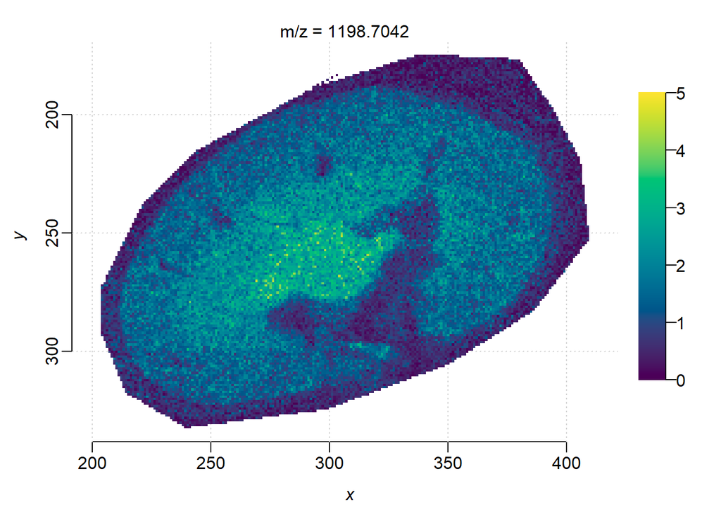

```r
m <- 1198.7
image(peaks_timsimaging, i = findInterval(m, mz(peaks_timsimaging))+1, zlim=c(0, 5))
```

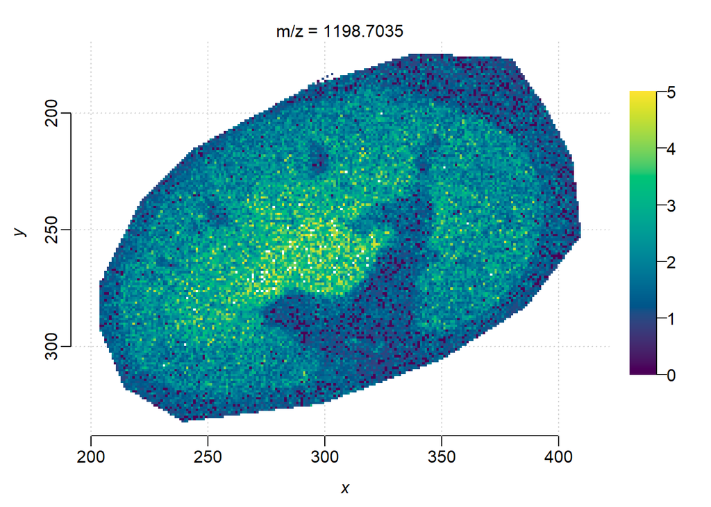

```r
image(peaks_norm, mz = m, zlim=c(0, 5))
```

The ion images from TIMSCONVERT and processed in Cardinal looks noiser, as well as less contrast between the background and kidney edge.

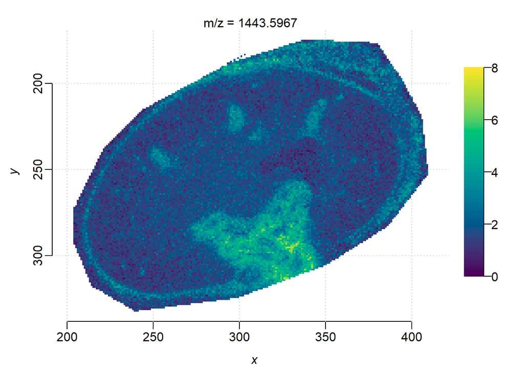

```r
m <- 1443.59
image(peaks_timsimaging, i = findInterval(m, mz(peaks_timsimaging))+1, zlim=c(0, 8))
```

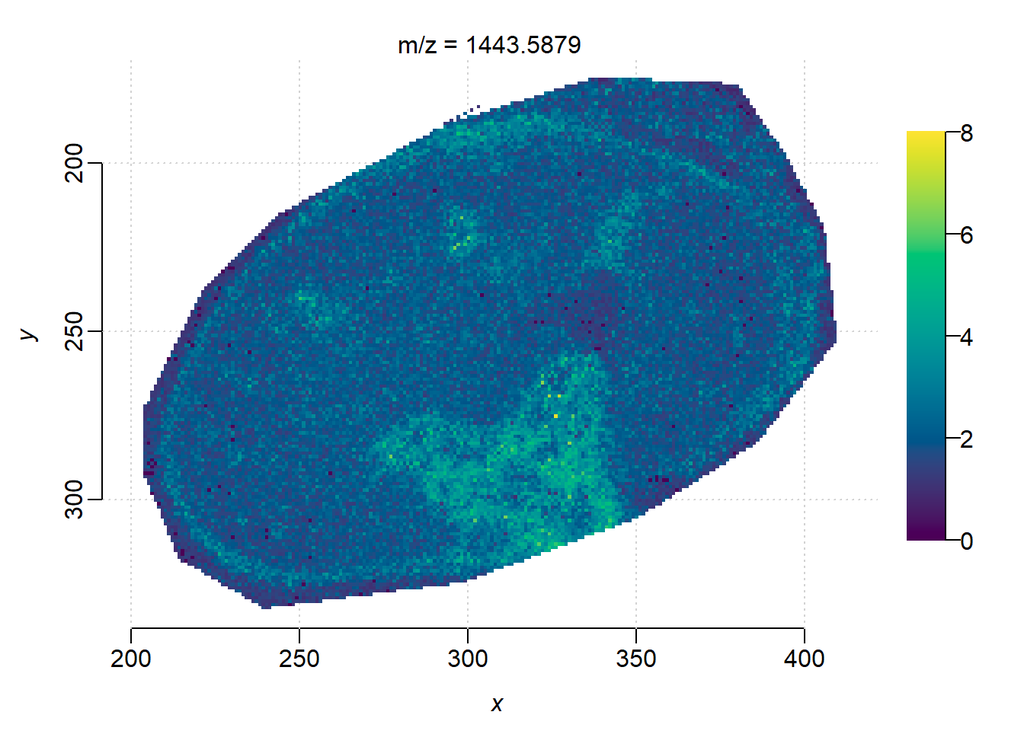

```r
image(peaks_norm, mz = m, zlim=c(0, 8))
```